# Computing Homework 2

Due: Wednesday 12/6 at 11:59pm, Canvas submission

### Honor Pledge

**On my honor, I have neither received nor given any unauthorized assistance on this Homework.**

- SIGNED: 218007361

```r
# Load packages
library(ggplot2)
library(rstanarm)
library(bayesplot)
library(bayesrules)
library(tidyverse)
library(tidybayes)
library(broom.mixed)
```

We will use `penguins_data` (generated for you below) to build various models of penguin `body_mass_g`. Throughout, we’ll utilize weakly informative priors and a basic understanding that the average penguin weighs somewhere between 3,500 and 4,500 grams. One predictor of interest is penguin species: `Adelie` or `Gentoo`.

```r
penguin_data <- penguins_bayes %>%
  filter(species %in% c("Adelie", "Gentoo")) %>%
  select(flipper_length_mm, body_mass_g, species) %>%
  na.omit()
```

## 1. Modeling Main Effects (3pt)

Let’s begin our analysis of penguin `body_mass_g` by exploring its relationship with `flipper_length_mm` and `species`.

#### Q: Plot and summarize the observed relationships among these three variables. (0.5pt)

Hint: use `ggplot()` and set `color = species` to color the two types of penguins differently.

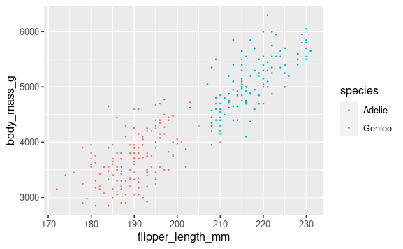

```r
ggplot(penguin_data, aes(x=flipper_length_mm, y=body_mass_g, col=species)) + geom_point(size=0.2)
```

#### Q: Use `stan_glm()` to simulate a posterior Normal regression model of `body_mass_g` by `flipper_length_mm` and `species`, without an interaction term. (0.5pt)

```r
penguin_main <- stan_glm(
  body_mass_g ~ flipper_length_mm + species,
  data = penguin_data, family = gaussian,
  prior_intercept = normal(4500, 500),
  prior = normal(0, 5, autoscale = TRUE),
  prior_aux = exponential(1, autoscale = TRUE),
  chains = 4, iter = 5000*2, seed = 84735)
```

#### Q: Create and interpret both visual and numerical diagnostics of your MCMC simulation. (0.5pt)

```r
prior_summary(penguin_main)
```

```
Priors for model 'penguin_main'
------
Intercept (after predictors centered)
 ~ normal(location = 4500, scale = 500)

Coefficients
  Specified prior:
    ~ normal(location = [0,0], scale = [5,5])
  Adjusted prior:
    ~ normal(location = [0,0], scale = [ 277.76,8387.97])

Auxiliary (sigma)
  Specified prior:
    ~ exponential(rate = 1)
  Adjusted prior:
    ~ exponential(rate = 0.0012)
------
See help('prior_summary.stanreg') for more details
```

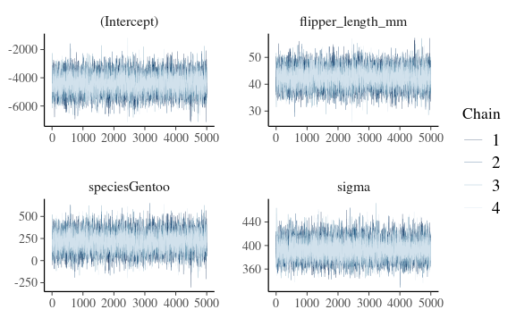

```r
mcmc_trace(penguin_main, size=0.1)
```

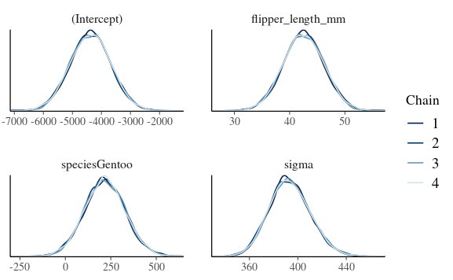

```r
mcmc_dens_overlay(penguin_main)
```

The autoscaled features of our model were found to be: prior = normal(0, 277.76), normal(0, 8387.97) sigma = exp(0.0012)

The trace plot of our variables seem to show our model mixing well. The density overlays suggest the same.

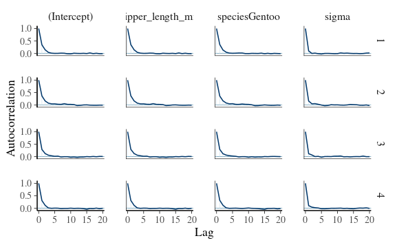

```r
mcmc_acf(penguin_main)
```

```r
neff_ratio(penguin_main)
```

```
      (Intercept) flipper_length_mm     speciesGentoo
          0.45895           0.45455           0.44825
            sigma
          0.72730
```

```r
rhat(penguin_main)
```

```
      (Intercept) flipper_length_mm     speciesGentoo
        1.0000971         1.0000955         1.0002064
            sigma
        0.9999555
```

The autocorrelation drops off quick for each chain, suggesting each mcmc draw mimics independence. neff_ratio > 0.1 and rhat < 1.05, which suggests it mixes fast and has similar variance across each parallel chain.

#### Q: Produce a `tidy()` summary of this model. Interpret the non-intercept coefficients’ posterior median values in context. (0.5pt)

```r
tidy(penguin_main, effects = c("fixed", "aux"))
```

| term | estimate | std.error |
| --- | --- | --- |
| (Intercept) | -4373.78136 | 704.375794 |
| flipper_length_mm | 42.51283 | 3.703816 |
| speciesGentoo | 216.92383 | 112.076597 |
| sigma | 392.67753 | 17.038478 |
| mean_PPD | 4318.53295 | 33.816816 |

For every unit of flipper_length_mm, body_mass_g increases 42.513 units. Between the species types, there is a difference of 216.92 units of body_mass_g. The average standard deviation of this model is 392.68 units. The mean body mass is 4318.53 units with a standard deviation of 33.82.

#### Q: Simulate, plot, and describe the posterior predictive model for the body mass of an `Adelie` penguin that has a flipper length of 197. (1pt)

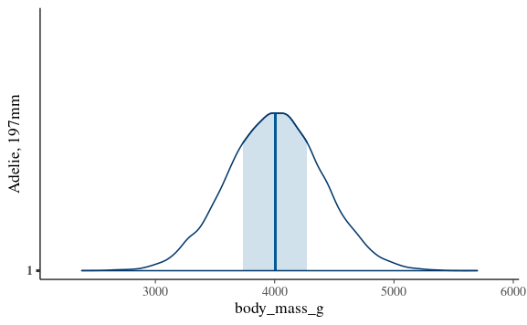

```r
Adelie197_prediction <- posterior_predict(penguin_main,
  newdata = data.frame(flipper_length_mm <- c(197),
                       species <- c('Adelie'))
)
mcmc_areas(Adelie197_prediction) + xlab("body_mass_g") + ylab("Adelie, 197mm")
```

For an Adelie penguin with flippers the length of 197mm, the average body mass is around 4000g.

## 2. Modeling Interaction (3pt)

Building from the previous exercise, our next goal is to model `body_mass_g` by `flipper_length_mm` and `species` with an **interaction** term between these two predictors.

#### Q: Use `stan_glm()` to simulate the posterior for this model, with four chains at 10,000 iterations each. (1pt)

```r
penguin_interact <- stan_glm(
  body_mass_g ~ flipper_length_mm + species + flipper_length_mm:species,
  data = penguin_data, family = gaussian,
  prior_intercept = normal(4500, 500),
  prior = normal(0, 5, autoscale = TRUE),
  prior_aux = exponential(1, autoscale = TRUE),
  chains = 4, iter = 5000*2, seed = 84735)
```

#### Q: Simulate and plot 50 posterior model lines. Briefly describe what you learn from this plot. (1pt)

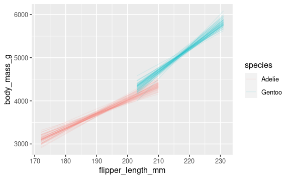

```r
penguin_data %>%
  add_fitted_draws(penguin_interact, n = 50) %>%
  ggplot(aes(x=flipper_length_mm, y=body_mass_g, color=species)) +
    geom_line(aes(y=.value, group=paste(species, .draw)), alpha=0.1)
```

#### Q: Produce a `tidy()` summary for this model. Based on the summary, do you have evidence that the interaction terms are necessary for this model? Explain your reasoning. (1pt)

```r
tidy(penguin_interact, effects = c("fixed", "aux"),
     conf.int = TRUE, conf.level = 0.8) %>%
  select(-std.error)
```

| term | estimate | conf.low | conf.high |
| --- | --- | --- | --- |
| (Intercept) | -2653.38852 | -3827.27100 | -1484.34869 |
| flipper_length_mm | 33.45768 | 27.28455 | 39.61458 |
| speciesGentoo | -3971.23924 | -5837.59765 | -2094.30180 |
| flipper_length_mm:speciesGentoo | 20.44008 | 11.32477 | 29.49651 |
| sigma | 387.53200 | 367.52505 | 409.64158 |
| mean_PPD | 4318.03061 | 4275.20807 | 4360.70981 |

## 3. Model Comparison (4pt)

#### Q: Produce and compare the `pp_check()` plots for both models above (`penguin_main` and `penguin_interact`). (1pt)

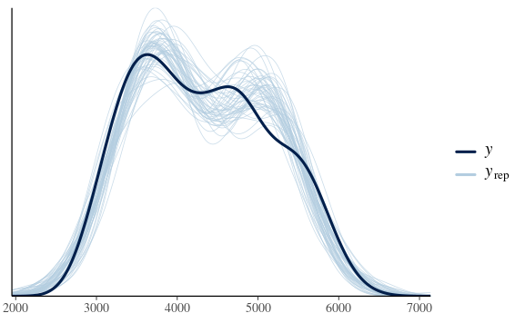

```r
pp_check(penguin_main)
```

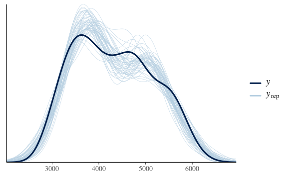

```r
pp_check(penguin_interact)
```

#### Q: Use 10-fold cross-validation to assess and compare the posterior predictive quality of the two models using `prediction_summary_cv()`. (1pt)

**Note**: this step might take some time! In addition, you will want to `set.seed()` at some seed value before running `prediction_summary_cv()` in order to reproduce your results.

```r
set.seed(84735)
prediction_summary_cv(model = penguin_main,
                      data = penguin_data, k = 10)
```

| fold | mae | mae_scaled | within_50 | within_95 |
| --- | --- | --- | --- | --- |
| 1 | 291.7689 | 0.7412312 | 0.4642857 | 0.9285714 |
| 2 | 359.1083 | 0.9084590 | 0.3703704 | 0.9629630 |
| 3 | 278.0164 | 0.7158447 | 0.4444444 | 0.9259259 |
| 4 | 236.3362 | 0.6032538 | 0.5357143 | 0.9285714 |
| 5 | 328.6551 | 0.8213442 | 0.4074074 | 0.9629630 |
| 6 | 300.3992 | 0.7639139 | 0.4444444 | 0.9629630 |
| 7 | 229.7054 | 0.5725455 | 0.5357143 | 0.9642857 |
| 8 | 323.0117 | 0.8249749 | 0.4074074 | 0.8888889 |
| 9 | 184.6524 | 0.4513300 | 0.6666667 | 1.0000000 |
| 10 | 271.5102 | 0.6773446 | 0.5000000 | 1.0000000 |

| mae | mae_scaled | within_50 | within_95 |
| --- | --- | --- | --- |
| 280.3164 | 0.7080242 | 0.4776455 | 0.9525132 |

```r
set.seed(84735)
prediction_summary_cv(model = penguin_interact,
                      data = penguin_data, k = 10)
```

| fold | mae | mae_scaled | within_50 | within_95 |
| --- | --- | --- | --- | --- |
| 1 | 235.1880 | 0.6013974 | 0.5357143 | 0.9285714 |
| 2 | 313.7863 | 0.8092109 | 0.4074074 | 0.9629630 |
| 3 | 269.6230 | 0.7080452 | 0.4074074 | 0.8888889 |
| 4 | 307.5274 | 0.8051625 | 0.4642857 | 0.8928571 |
| 5 | 411.7773 | 1.0508281 | 0.4074074 | 0.9629630 |
| 6 | 263.5868 | 0.6751313 | 0.5185185 | 0.9629630 |
| 7 | 204.4514 | 0.5156559 | 0.5714286 | 0.9642857 |
| 8 | 261.3623 | 0.6833286 | 0.4444444 | 0.8888889 |
| 9 | 192.9886 | 0.4837631 | 0.7037037 | 1.0000000 |
| 10 | 243.9403 | 0.6133414 | 0.6071429 | 1.0000000 |

| mae | mae_scaled | within_50 | within_95 |
| --- | --- | --- | --- |
| 270.4231 | 0.6945864 | 0.506746 | 0.9452381 |

```
NA
```

#### Q: Evaluate and compare the ELPD posterior predictive accuracy of the two models. (1pt)

```r
set.seed(84735)
loo_main <- loo(penguin_main)
loo_interact <- loo(penguin_interact)
loo_compare(loo_main, loo_interact)
```

```
                 elpd_diff se_diff
penguin_interact  0.0       0.0
penguin_main     -3.7       2.4
```

#### Q: In summary, which one of the two models is ``better?’’ Explain. (1pt)

Of the two models it seems that penguin_interact performs slightly better than penguin_main; However, their metrics are close, and not statistically significant enough. While penguin_interact performs better in mae and within_50, it is less accurate within_95. Also, when evaluating predictive accuracy using expected log-predictive densities, penguin_interact outperforms penguin_main, but only by one se_diff, not two; Meaning, there may be a difference, but it is not a significantly greater difference.